# Reproducible Research: Peer Assessment 1

## Loading and preprocessing the data

Data is in `activity.zip`, included in this repository. It must be unzipped and read in:

```r
unzip("activity.zip")
data <- read.csv("activity.csv")
data$date <- as.Date(data$date)
```

## What is mean total number of steps taken per day?

To determine the mean total number of steps taken per day, we can use the `aggregate` function to sum steps per date:

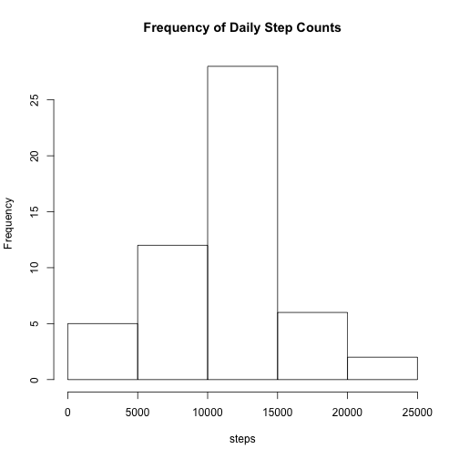

```r
by.date <- aggregate(steps ~ date, data=data, FUN=sum, na.rm=TRUE)
steps <- by.date$steps
hist(steps, main="Frequency of Daily Step Counts")
```

We use the the `mean` and `median` functions to find the mean and median steps taken in one day:

```r
mean(steps)
```

```
## [1] 10766
```

```r
median(steps)
```

```
## [1] 10765
```

## What is the average daily activity pattern?

We once again use `aggregate` to average the number of steps for each 5-minute interval across all days:

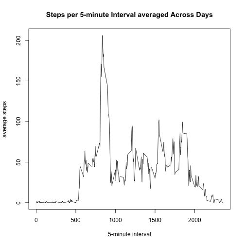

```r
by.interval <- aggregate(steps ~ interval, data=data, FUN = mean, na.rm=TRUE)
names(by.interval) <- c("5-minute interval", "average steps")
plot(by.interval, type="l", main="Steps per 5-minute Interval averaged Across Days")
```

We use the `max` function to find the most busy daily interval:

```r
by.interval[which.max(by.interval$"average steps"),]
```

```
##     5-minute interval average steps
## 104               835         206.2
```

## Imputing missing values

Of `17568` observations in our data, we're missing `2304` of them. To fill this out without a lot of complexity, we can use the means for the corresponding intervals for days for which we do have data (which we computed above).

```r
by.interval <- aggregate(steps ~ interval, data=data, FUN = mean, na.rm=TRUE)
imputed.data <- merge(data, by.interval, by="interval", suffixes=c("",".mean"), all = TRUE)
NAs <- is.na(imputed.data$steps)
imputed.data$steps[NAs] <- imputed.data$steps.mean[NAs]
```

Now let's perform our previous exploration using the *imputed* data:

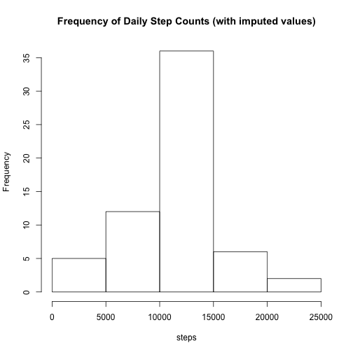

```r
imputed.by.date <- aggregate(steps ~ date, data=imputed.data, FUN=sum, na.rm=TRUE)
steps <- imputed.by.date$steps
hist(steps, main="Frequency of Daily Step Counts (with imputed values)")
```

```r
mean(steps)
```

```
## [1] 10766
```

```r
median(steps)
```

```
## [1] 10766
```

We see no significant change upon imputing values using our simple method; just a small upward increment of the median.

## Are there differences in activity patterns between weekdays and weekends?

Let's start by labeling days using the `weekdays` function and some quick string-replacement, then taking the mean number of steps per interval for each category:

```r
imputed.data$day.type <- gsub("[A-Za-z]*day", "weekday", gsub("Saturday|Sunday", "weekend", weekdays(imputed.data$date)))
by.daytype.interval <- aggregate(steps ~ interval+day.type, data=imputed.data, FUN = mean, na.rm=TRUE)
```

Then we plot them each as above and make a panel-plot to juxtapose them:

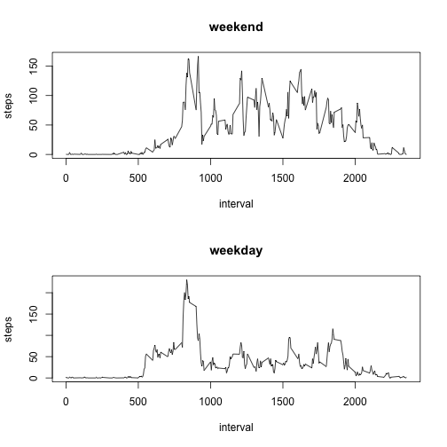

```r
par(mfcol=c(2,1))
plot(by.daytype.interval[grep("weekend", by.daytype.interval$day.type), c(1,3)], type='l', main="weekend")
plot(by.daytype.interval[grep("weekday", by.daytype.interval$day.type), c(1,3)], type='l', main="weekday")
```

We can see from this juxtaposition that the subjects of the data observations tend to be more active throughout the day on weekends, possibly because they spend most of weekdays sitting at a desk at work.